# Houston City Council: local ideal points, 2021–2025

Pooled roll calls, 2021–2025, with both mayors · Preliminary analysis

Author

Boris Shor

Updated

October 8, 2026

Houston’s contested roll calls produce a clear one-dimensional spectrum even though the city’s elections are nonpartisan. Republican-affiliated members, led by Fred Flickinger, Greg Travis, Mike Knox, and Mary Nan Huffman, form one end. Letitia Plummer, Edward Pollard, Tarsha Jackson, and Tiffany Thomas form the other. Mayor Sylvester Turner sits with the council’s Democratic majority; Mayor John Whitmire sits near the center, beside the Republican-endorsed at-large members elected with him in 2023. The ordering matches public party affiliation closely and is strongly associated with 2024 presidential voting across the eleven district seats.

**25 officials**  
Including both mayors

**2 mayors**  
Turner and Whitmire

**119 roll calls**  
Contested council decisions

**1,869 votes**  
Recorded yeas and nays

## Dataset

The roll calls come from an extraction of the official Houston City Council minutes, plus five contested actions missing from it that we verified page by page and added separately. Source checks, provenance, and the audit trail are recorded with the project’s analysis files.

### Coverage and construction

[output not shown]

Yea is coded 1 and nay 0. Absences, early departures, and names omitted from an explicit roll call are missing, never nays. Houston records the great majority of actions as unanimous or near-unanimous. Only **119 actions** have at least two officials on each side, and these form the scale. Unanimous and single-dissent actions may matter substantively, but they carry almost no information about relative positions. Recorded disagreement is therefore scarce, and the retained votes are a selected subset of council business.

| Year | Retained contested actions |
| --- | --- |
| 2021 | 36 |
| 2022 | 22 |
| 2023 | 26 |
| 2024 | 20 |
| 2025 | 15 |

## Results

### Council ideal points

An **ideal point** is a one-dimensional summary of voting similarity. Members placed near one another tend to take the same side on contested roll calls; members far apart tend to oppose one another. A single position is estimated for each official across 2021–2025. The units are specific to this Houston sample, so the scores cannot be compared numerically with the Chicago, Denver, or New York scores. Positive values are displayed on the side where Amy Peck falls, as a display convention only.

The technical appendix covers estimation and checks on the stability of these positions.

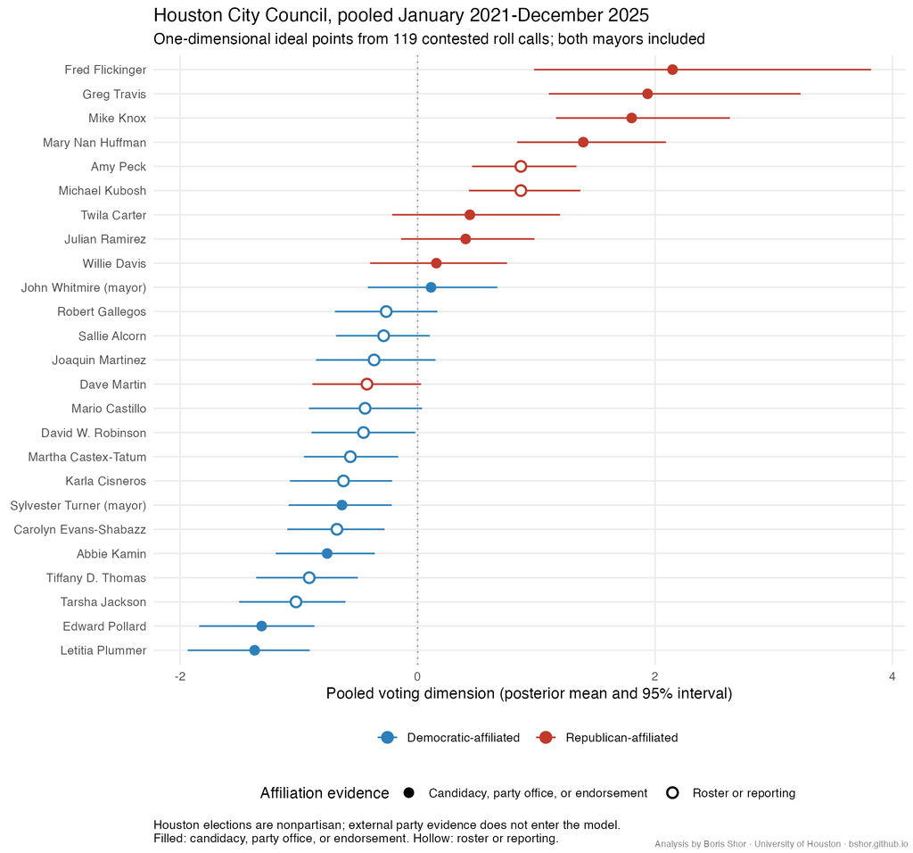

Pooled Houston ideal points for all 25 voting officials, 2021–2025. Color gives externally researched Democratic or Republican affiliation. Filled points rest on a party endorsement, party office, or party candidacy; hollow points rest on a council roster or reporting. Intervals are 95% posterior intervals.

### Individual members and policy controversies

The positive endpoint is **Fred Flickinger** (2.15), followed by **Greg Travis** (1.94), **Mike Knox** (1.80), and **Mary Nan Huffman** (1.40). Flickinger’s interval is wide because he has served only since 2024 and cast 34 retained votes. The negative endpoint is **Letitia Plummer** (-1.37) and **Edward Pollard** (-1.31), followed by **Tarsha Jackson** (-1.02) and **Tiffany Thomas** (-0.91).

Of the 119 retained actions, 33 place every present member of these two endpoint groups on opposite sides. The vote splits below come from the official roll calls in our data, and the linked coverage describes what each dispute was about.

- **Conservation districts (Ordinance 2023-0232, April 2023).** The ordinance let residents of several historically Black and Latino neighborhoods adopt development standards meant to slow redevelopment and displacement. It passed 13–4, with Peck, Martin, Huffman, and Knox voting no; opponents objected to new limits on property owners. [Houston Chronicle](https://www.houstonchronicle.com/politics/houston/article/houston-creates-conservation-districts-17878204.php); [Houston Public Media](https://www.houstonpublicmedia.org/articles/news/city-of-houston/2023/04/05/448401/houston-city-council-approves-conservation-districts-with-hopes-of-protecting-six-historic-neighborhoods/)
- **Gun buyback funding (Motion 2022-0428, August 2022).** The motion authorized $539,000 in federal relief funds for gift cards for Houston Police Department gun buybacks. It passed 12–4 over the no votes of Peck, Huffman, Knox, and Kubosh, amid questions about whether anonymous buybacks reduce gun crime. [KPRC](https://www.click2houston.com/news/local/2022/08/23/houston-council-seeking-to-approve-539000-for-future-gun-buyback-programs-research-shows-it-doesnt-deter-gun-crime/)
- **Property tax rate (Ordinance 2023-0627, September 2023).** Council cut the rate slightly while total revenue still rose because appraised values had increased. Peck, Huffman, Knox, and Kubosh voted no on the levy, 12–4. [Houston Chronicle](https://www.houstonchronicle.com/politics/houston/article/houston-tax-rate-cut-increase-18365317.php)
- **Disaster-recovery housing (Ordinance 2025-0569, August 2025).** A floor amendment by Tiffany Thomas moved $50 million of federal storm-recovery funds from power generation to home repair, doubling the housing allocation to $100 million. The amended plan passed 12–3, with Peck, Flickinger, and Huffman opposed. [KPRC](https://www.click2houston.com/news/local/2025/08/13/houston-city-council-approves-amended-disaster-recovery-plan-allocates-100-million-for-housing-repair/)
- **I-45 right-of-way sale (Ordinance 2025-0055, January 2025).** The city sold land along White Oak Bayou to TxDOT for the contested North Houston Highway Improvement Project. District H’s Mario Castillo argued for easements that would better protect the bayou trail. The recorded roll call is 9–7: Plummer, Pollard, Jackson, Thomas, Kamin, Evans-Shabazz, and Castillo opposed, while Peck, Huffman, Flickinger, and Mayor Whitmire voted yes. [ABC13](https://abc13.com/post/city-houston-approves-controversial-sale-land-txdot-45/14858675/)

Across these examples, the positive end opposes taxation, new land-use regulation, and redistributive or gun-violence spending; the negative end supports them and opposes highway expansion through older neighborhoods. This is consistent with a Democratic-progressive versus Republican-conservative interpretation, with a strong fiscal component. The examples illustrate the dimension; they do not establish that every retained vote shares this content. Summary news coverage sometimes reports different tallies from the official roll call; the counts here follow the roll calls.

### The two mayors

**Sylvester Turner** (-0.64) sits among the Democratic district members who formed his governing majority. **John Whitmire** (0.11) is close to the center. That placement is consistent with his reputation as a moderate Democrat who campaigned on public safety and fiscal restraint. On the I-45 land sale, for example, he voted with the Republican-affiliated members against most of the council’s negative end. Mayors rarely lose council votes and vote on only some contested actions, so their scores should be read as coalition positions rather than full policy platforms.

### 2024 presidential vote by council district

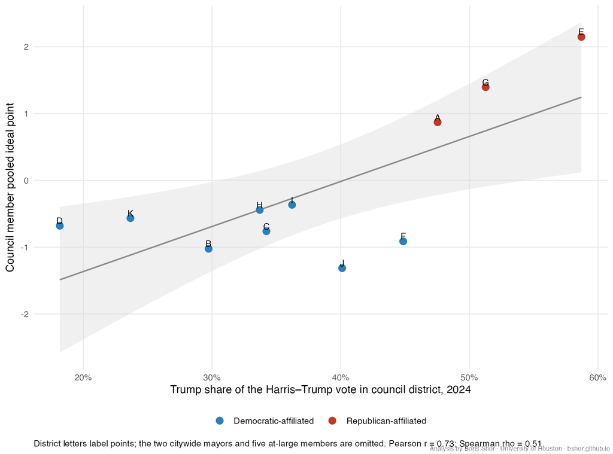

Council-district presidential voting and the pooled ideal point of the member serving that district on November 5, 2024. Letters identify districts; the mayors and at-large members have no single district and are omitted.

The comparison uses the *New York Times* published 2024 precinct results and the city’s council-district boundaries. Houston precincts frequently cross council boundaries, so each precinct’s votes are divided among districts in proportion to area. This assumes voters are spread evenly within each precinct. The allocation places **455,915 Harris votes** and **289,333 Trump votes** inside the city’s districts. [*New York Times* precinct-data documentation](https://github.com/nytimes/presidential-precinct-map-2024)

District presidential voting closely tracks council voting positions: the Pearson association is **0.73**. The three most Republican districts, E, G, and A, elected the three Republican-affiliated district members. Districts F and J are the clearest exceptions: both are relatively competitive by Houston standards, yet Thomas and Pollard are near the negative end. With eleven observations and area-based allocation, this is supporting evidence rather than a precise estimate. The regression details are in the technical appendix.

### Partisan affiliation

Houston’s ballots do not list party, so affiliation was coded from external evidence of differing strength:

- **Party record:** a documented partisan candidacy or party office, not voter registration or a council ballot line.
- **Party endorsement:** support in a nonpartisan council race from the Harris County Republican Party ([November](https://www.harriscountygop.com/wp-content/uploads/2023/10/November-2023-Election-Harris-County-GOP-Endorsed-Candidates-3.pdf); [December runoff](https://www.harriscountygop.com/wp-content/uploads/2023/11/Harris-County-GOP-Endorsed-Candidates-1.pdf)). This signals alignment but does not alone establish party membership.
- **Secondary roster:** a [current council roster](https://en.wikipedia.org/wiki/Houston_City_Council) listing party.
- **Reporting only:** a news or biographical characterization.

David Robinson and Karla Cisneros are coded Democratic-affiliated from a [contemporaneous Houston Chronicle report](https://www.govtech.com/em/disaster/City-Council-Adopts-Stricter-Development-Rules-for-Houstons-Floodplains.html), republished by Government Technology, that identifies both explicitly; this is reporting-tier evidence, not a party record. No official in the data won office with a Houston DSA endorsement, and no formal ideological caucus was identified, so the DSA and caucus comparisons used for the other cities are not available.

Michael Kubosh is coded Republican-affiliated from [contemporaneous *Texas Monthly* reporting](https://web.archive.org/web/20210513000446/https://www.texasmonthly.com/news-politics/here-comes-trouble/) that describes his 2006 Democratic Senate candidacy as tactical, corroborated by a [2019 *Houston Chronicle* profile](https://web.archive.org/web/20230208205501/https://www.houstonchronicle.com/news/houston-texas/houston/article/Houston-council-runoff-foes-are-opposites-in-14867953.php) reporting GOP endorsements and Republican ballots in eight of nine earlier primaries. He now rejects party labels, and no Republican party office or candidacy is documented; accordingly his evidence tier is **reporting only**, not party record. His voting score did not determine this coding.

| Group | In group | Others | Median: group | Median: others | Median difference |
| --- | --- | --- | --- | --- | --- |
| Republican-affiliated (any source) | 10 | 15 | 0.87 | -0.62 | 1.49 |
| Republican candidacy or party office (vs. all others) | 3 | 22 | 1.80 | -0.43 | 2.24 |
| Harris County GOP-endorsed in 2023 (current term only) | 5 | 12 | 0.44 | -0.62 | 1.06 |
| Democratic-affiliated (any source) | 15 | 10 | -0.62 | 0.87 | -1.49 |

The 2021–2025 report plots **25 officials**, all included in the two-party rows. “Others” means everyone outside each named group; the candidacy/office row also excludes Republicans whose evidence is only an endorsement, roster, or reporting. The 2023 endorsement row compares the five GOP-endorsed members with the other 12 officials in that council term. Republican-affiliated officials have a median of 0.87, compared with -0.62 for Democratic-affiliated officials. The five 2023 Republican-endorsed members also sit to the positive side of the current council. The main exception is **Dave Martin** (-0.43), classified Republican from reporting rather than a party record, who voted with the Turner-era majority. Kubosh is included on the strength of external reporting, not his voting score. These are descriptive associations using posterior means, not causal estimates.

## Interpretation and limits

Houston’s contested votes distinguish party-affiliated coalitions and recognizable policy disputes. The middle of the council has overlapping intervals, and divided votes are a selected part of its business. Detailed construction and estimation limits are in the technical appendix.